# 20210224_DEG_heatmap

Gijsje

2/24/2021

# DEG across stimulations FDR % log FC > 1 or -1

#210 genes

```r
LPS <- read.csv("~/Documents/MiGASti/Databases/res_name_LPS_LFC1.txt", sep="")
IFNy <- read.csv("~/Documents/MiGASti/Databases/res_name_IFNy_LFC1.txt", sep="")

genes_LPS <- LPS$ensembl
genes_IFNy <- IFNy$ensembl

# create a vector with all genes listed
x <- c(genes_LPS, genes_IFNy)
# make a dataframe
as.data.frame(x)
# check if there are genes duplicate
duplicated(x)
unique(x)
#remove duplicated
ensembl <- x[!duplicated(x)] #1204 genes

genelist <- as.data.frame(ensembl)
ensembl <- genelist$ensembl[!duplicated(genelist$ensembl)]
genelist <- as.data.frame(ensembl)
genelist %>% distinct(ensembl, .keep_all = TRUE)

load("~/Documents/MiGASti/res_name_LPS2.Rdata")
load("~/Documents/MiGASti/docs/res_name_IFNy2.Rdata")

DEG_genes_LPS = merge(res_name_LPS2, genelist, by ="ensembl")
DEG_genes_IFNy = merge(res_name_IFNy2, genelist, by = "ensembl")

Expression_stimulations <- cbind(DEG_genes_LPS, DEG_genes_IFNy)

as.data.frame(Expression_stimulations)
# changes names in data frame
names(Expression_stimulations)[2] <- "LPS"
names(Expression_stimulations)[10] <- "IFNy"

DF_log2FC <- Expression_stimulations %>% select(1, 2, 10)
DF <- as.data.frame(DF_log2FC)
DF <- t(DF)
head( DF )[,1:10]

# fill NA with 0
DF_log2FC[is.na(DF_log2FC)] = 0
save(DF_log2FC, file = "Kmeans210gsupport_LPS_IFNy.Rdata")

gencode <- read.delim("~/Documents/MiGASti/Databases/ens.geneid.gencode.v30")
gencode$ensembl = gencode$gene_id
DF_log2FC <- merge(gencode, DF_log2FC, by = "ensembl")
DF_log2FC$symbol = DF_log2FC$GeneSymbol

# remove the first column
df_num = as.matrix(DF_log2FC[,4:5])
# scale the data
df_num_scale = scale(df_num)
save(df_num, file = "df_num_LPS_IFNy_LOGFC1.Rdata")
#save(DF_log2FC, file = "LOGFC1_stimulations_LPS_IFNy.Rdata")
save(df_num_scale, file = "df_num_scale_LOGFC1stim_LPS_IFNy.Rdata")
```

### Overlap 210 genes with Patir

```r
gencode <- read.delim("~/Documents/MiGASti/Databases/ens.geneid.gencode.v30")
gencode$ensembl = gencode$gene_id
genelist <- merge(gencode, genelist, by = "ensembl")
genelist$symbol = genelist$GeneSymbol
Patir <- read.csv("~/Documents/MiGASti/Databases/Patir.txt", sep="")
names(Patir)[1] <- "symbol"
overlap1 <- merge(Patir, genelist, by = "symbol")
list(overlap1$symbol)
```

[[1]] [1] “C1QB” “C2” “CD300A” “CIITA” “EBI3” “FCGR1A” “FCGR1B” [8] “FGL2” “GIMAP2” “GPR183” “HAMP” “IFI30” “IRF5” “LILRB2” [15] “MPEG1” “SLC37A2” “TRIM22”

### Heatmap DEG

#210 genes (scaling data)

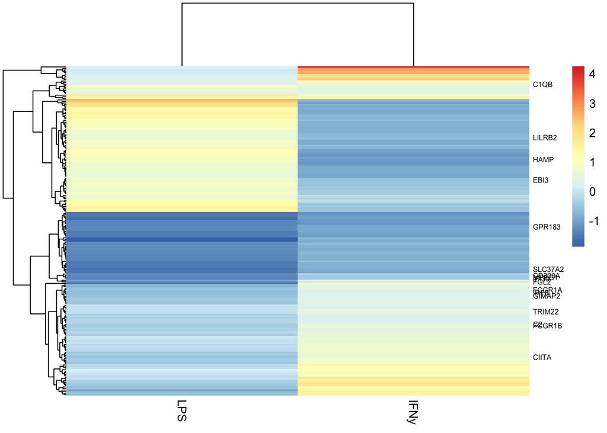

```r
rownames(DF_log2FC) = DF_log2FC$symbol
genelist <- c("C1QB",    "C2",      "CD300A",  "CIITA",   "EBI3",    "FCGR1A", "FCGR1B",  "FGL2",    "GIMAP2",  "GPR183", "HAMP",    "IFI30", "IRF5",    "LILRB2",  "MPEG1",   "SLC37A2", "TRIM22" )

labels <- rownames(DF_log2FC)
labels[!labels %in% genelist] <- ""
pheatmap(df_num_scale, labels_row = labels, fontsize_row = 6)
```

### Correlation between log FC LPS and IFNy (Spearman)

```r
df <- as.data.frame(df_num_scale)
res <- cor.test(df$LPS, df$IFNy, method = "spearman")
res
```

```
Spearman's rank correlation rho
```

data: df$LPS and df$IFNy S = 1618656, p-value = 0.4823 alternative hypothesis: true rho is not equal to 0 sample estimates: rho -0.04871571

### PCA across stimulations

```r
dat <- data.frame(df_num_scale)
stimulation <- colnames(dat)
as.data.frame(stimulation)
```

| stimulation |
| --- |
| LPS |
| IFNy |

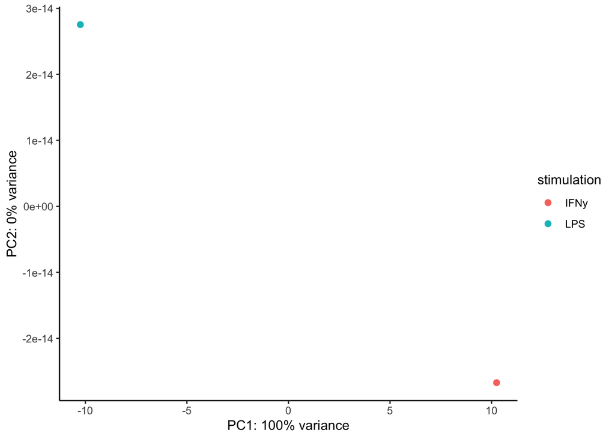

```r
dat <- data.frame(dat)
pca <- prcomp(t(dat), scale=TRUE)
PoV <- round((pca$sdev^2/sum(pca$sdev^2))*100)
#Grab covariates to plot:
library(ggplot2)
library(ggfortify)


#Plot:
ggplot(pca, aes(PC1, PC2, color=stimulation)) +
  geom_point(size=2) +
  xlab(paste0("PC1: ",PoV[1],"% variance")) +
  ylab(paste0("PC2: ",PoV[2],"% variance")) +
  theme_classic()
```

```r
list_filters = list(LPS = genes_LPS, IFNy = genes_IFNy)
#list_filters
overlap = unlist(list_filters)
```

### Upset plot

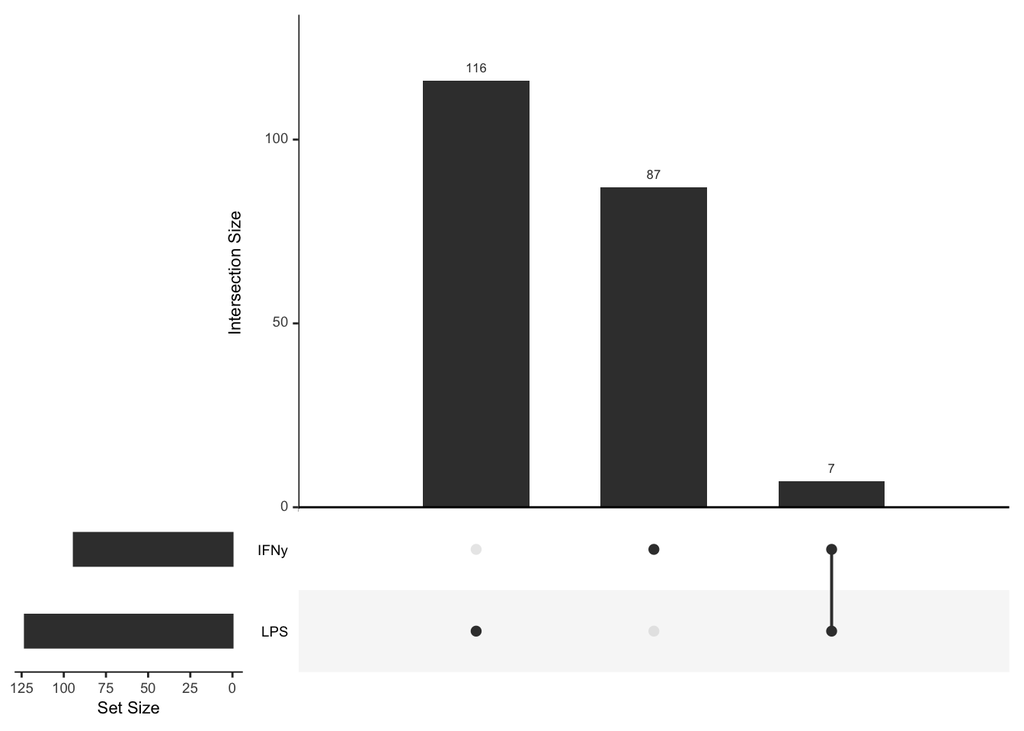

```r
upset(fromList(list_filters), order.by = "freq")
```

# DEG across stimulations FDR 5% in 2 stimulations

#348 genes

```r
DEG_LPS <- subset(res_name_LPS2, adj.P.Val < 0.05)
DEG_IFNy <- subset(res_name_IFNy2, adj.P.Val < 0.05)

genes_LPS <- DEG_LPS$ensembl
genes_IFNy <- DEG_IFNy$ensembl

# create a vector with all genes listed
x <- c(genes_LPS, genes_IFNy)
# make a dataframe
as.data.frame(x) #12590 genes
# check if there are genes duplicate
duplicated(x)
x[duplicated(x)]
unique(x)
#continue only with duplicated
ensembl <- x[duplicated(x)]

genelist <- as.data.frame(ensembl)
#remove duplicated
ensembl <- genelist$ensembl[!duplicated(genelist$ensembl)]
genelist <- as.data.frame(ensembl) #3159 genes

DEG_genes_LPS = merge(res_name_LPS2, genelist, by ="ensembl")
DEG_genes_IFNy = merge(res_name_IFNy2, genelist, by = "ensembl")

Expression_stimulations <- cbind(DEG_genes_LPS, DEG_genes_IFNy)

as.data.frame(Expression_stimulations)
# changes names in data frame
names(Expression_stimulations)[2] <- "LPS"
names(Expression_stimulations)[10] <- "IFNy"

DF_log2FC <- Expression_stimulations %>% select(1, 2, 10)
DF <- as.data.frame(DF_log2FC)
DF <- t(DF)
head( DF )[,1:10]

DF_log2FC <- merge(gencode, DF_log2FC, by = "ensembl")
DF_log2FC$symbol = DF_log2FC$GeneSymbol

# fill NA with 0
DF_log2FC[is.na(DF_log2FC)] = 0
save(DF_log2FC, file = "kmeans348gsupport_IFNy_LPS.Rdata")

# remove the first column
df_num = as.matrix(DF_log2FC[,4:5])
# scale the data
df_num_scale = scale(df_num)
# make rownames as function
rownames(df_num) = sapply(DF_log2FC$symbol,function(x)
strsplit(as.character(x),split = "\\\\")[[1]][1])
save(df_num, file = "df_num_FDR0.53stim_ensembl_LPS_IFNy.Rdata")
save(df_num_scale, file = "df_num_scale_FDR0.52stim_ensembl_LPS_IFNy.Rdata")
```

### Overlap 348 genes with Patir

```r
gencode <- read.delim("~/Documents/MiGASti/Databases/ens.geneid.gencode.v30")
gencode$ensembl = gencode$gene_id
genelist <- merge(gencode, genelist, by = "ensembl")
genelist$symbol = genelist$GeneSymbol
Patir <- read.csv("~/Documents/MiGASti/Databases/Patir.txt", sep="")
names(Patir)[1] <- "symbol"
overlap2 <- merge(Patir, genelist, by = "symbol")
list(overlap2$symbol)
```

[[1]] [1] “ADAM28” “ATP8B4” “C1QB” “CASP1” “CD53” “CD69”  
[7] “CD86” “CLEC17A” “CSF1R” “CTSC” “FCGR1A” “FGL2”  
[13] “GPR183” “HAMP” “HLA-DPA1” “HLA-DQB1” “HLA-DRA” “HLA-DRB1” [19] “HLA-DRB5” “IFI16” “IGSF6” “IRF5” “LPAR5” “NCF4”  
[25] “OLR1” “PTPN6” “PTPRC” “SIGLEC9” “SP140” “SP140L”  
[31] “TFEC” “TNFRSF1B” “TRIM22”

### Heatmap DEG

#348 genes

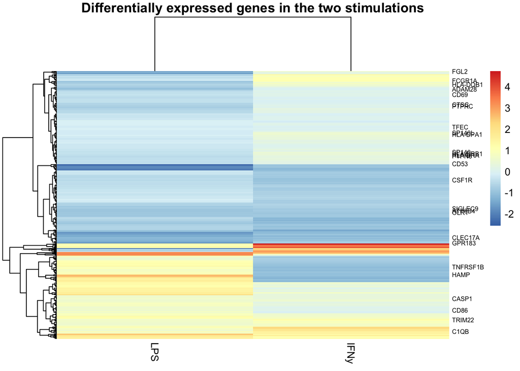

```r
rownames(DF_log2FC) = DF_log2FC$symbol
genelist <- c("ADAM28",   "ATP8B4",   "C1QB",    "CASP1",   "CD53",     "CD69", "CD86",   "CLEC17A",  "CSF1R",    "CTSC",  "FCGR1A",   "FGL2", "GPR183",   "HAMP",  "HLA-DPA1", "HLA-DQB1", "HLA-DRA",  "HLA-DRB1", "OLR1", "PTPN6",    "PTPRC", "SIGLEC9",  "SP140", "SP140L", "TFEC", "TNFRSF1B", "TRIM22")

labels <- rownames(DF_log2FC)
labels[!labels %in% genelist] <- ""
pheatmap(df_num_scale, labels_row = labels, main = "Differentially expressed genes in the two stimulations", fontsize_row = 6)
```

### Correlation between logFC LPS and IFNy (Spearman)

#348 genes

```r
df <- as.data.frame(df_num_scale)
res <- cor.test(df$LPS, df$IFNy, method = "spearman")
res
```

```
Spearman's rank correlation rho
```

data: df$LPS and df$IFNy S = 4546270, p-value = 1.682e-11 alternative hypothesis: true rho is not equal to 0 sample estimates: rho 0.3527496

### PCA across stimulations

```r
dat <- data.frame(df_num_scale)
stimulation <- colnames(dat)
as.data.frame(stimulation)
```

| stimulation |
| --- |
| LPS |
| IFNy |

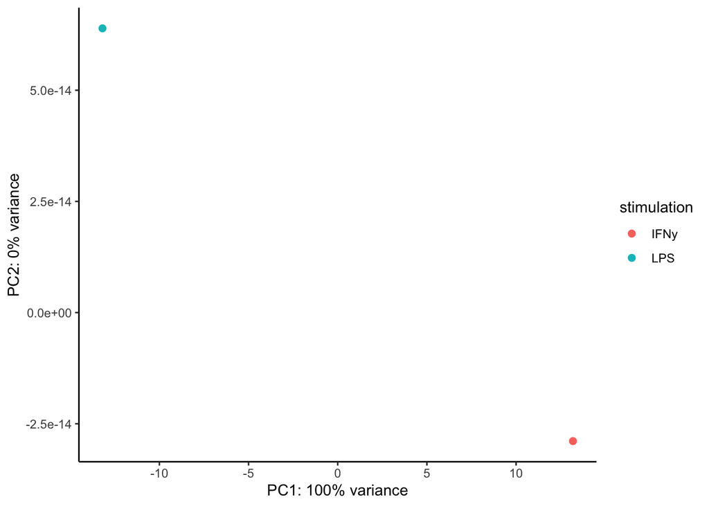

```r
dat <- data.frame(dat)
pca <- prcomp(t(dat), scale=TRUE)
PoV <- round((pca$sdev^2/sum(pca$sdev^2))*100)
#Grab covariates to plot:
library(ggplot2)
library(ggfortify)


#Plot:
ggplot(pca, aes(PC1, PC2, color=stimulation)) +
  geom_point(size=2) +
  xlab(paste0("PC1: ",PoV[1],"% variance")) +
  ylab(paste0("PC2: ",PoV[2],"% variance")) +
  theme_classic()
```

```r
list_filters = list(LPS = DEG_genes_LPS$symbol, IFNy = DEG_genes_IFNy$symbol)
#list_filters
overlap = unlist(list_filters)
```

### Upset plot

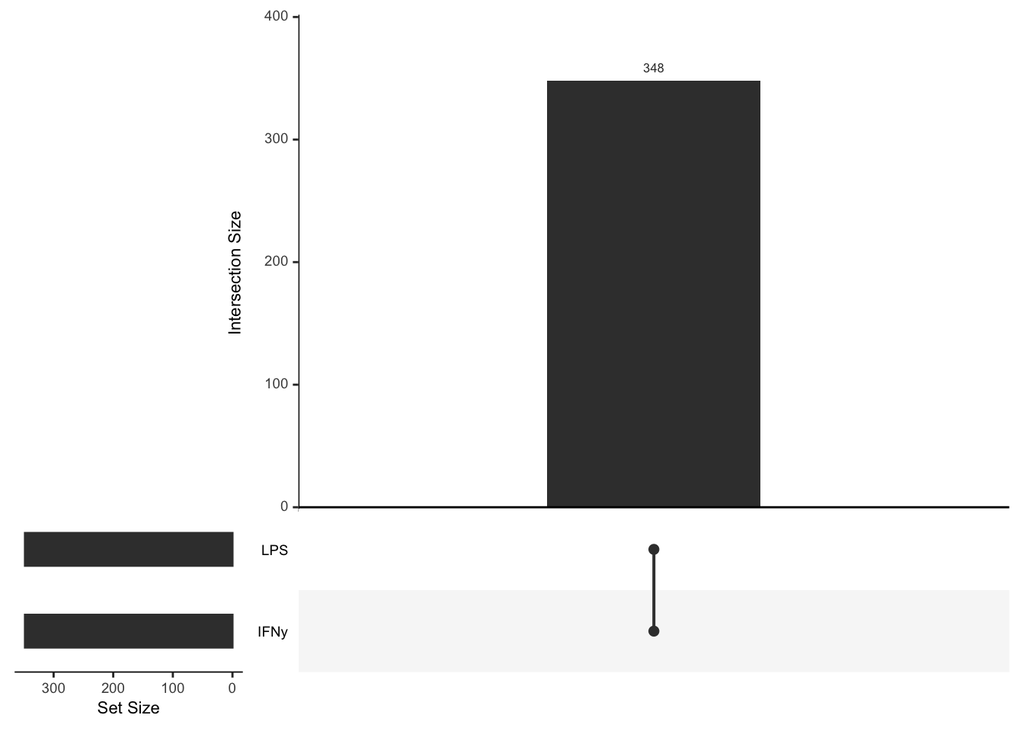

```r
upset(fromList(list_filters), order.by = "freq")
```

# DEG across stimulations FDR 5%

#6571 genes

```r
#check duplicated genes in list
#[1] "ATF7"    "TMSB15B" "POLR2J4" "MATR3"   "HSPA14"  "SCO2" "TBCE"    "ATXN7"   "ABCF2"   "POLR2J3" "GGT1"

DEG_LPS <- subset(res_name_LPS2, adj.P.Val < 0.05)
DEG_IFNy <- subset(res_name_IFNy2, adj.P.Val < 0.05)

genes_LPS <- DEG_LPS$ensembl
genes_IFNy <- DEG_IFNy$ensembl

# create a vector with all genes listed
x <- c(genes_LPS, genes_IFNy)
# make a dataframe
as.data.frame(x) #12590 genes
# check if there are genes duplicate
duplicated(x)
unique(x)
#remove duplicated
ensembl <- x[!duplicated(x)]

genelist <- as.data.frame(ensembl)
ensembl <- genelist$ensembl[!duplicated(genelist$ensembl)]
genelist <- as.data.frame(ensembl)
genelist %>% distinct(ensembl, .keep_all = TRUE)

DEG_genes_LPS = merge(res_name_LPS2, genelist, by ="ensembl")
DEG_genes_IFNy = merge(res_name_IFNy2, genelist, by = "ensembl")

Expression_stimulations <- cbind(DEG_genes_LPS, DEG_genes_IFNy)

as.data.frame(Expression_stimulations)
# changes names in data frame
names(Expression_stimulations)[2] <- "LPS"
names(Expression_stimulations)[10] <- "IFNy"

DF_log2FC <- Expression_stimulations %>% select(1, 2, 10)
DF <- as.data.frame(DF_log2FC)
DF <- t(DF)
head( DF )[,1:10]


# fill NA with 0
DF_log2FC[is.na(DF_log2FC)] = 0
save(DF_log2FC, file = "kmeans8523ensembl_LPS_IFNy.Rdata")

DF_log2FC <- merge(gencode, DF_log2FC, by = "ensembl")
DF_log2FC$symbol = DF_log2FC$GeneSymbol

#remove rownames that are duplicates (HSPA14)
DF_log2FC = DF_log2FC[-c(5404),]


# remove the first column
df_num = as.matrix(DF_log2FC[,4:5])
# scale the data
df_num_scale = scale(df_num)
# make rownames as function
rownames(df_num) = sapply(DF_log2FC$symbol,function(x)
strsplit(as.character(x),split = "\\\\")[[1]][1])
save(df_num, file = "df_num_FDR0.5stim_allgenes_ensembl_LPS_IFNy.Rdata")
save(df_num_scale, file = "df_num_scale_FDR0.5stim_allgenes_ensembl_LPS_IFNy.Rdata")
```

### Overlap 6571 genes with Patir

```r
gencode <- read.delim("~/Documents/MiGASti/Databases/ens.geneid.gencode.v30")
gencode$ensembl = gencode$gene_id
genelist <- merge(gencode, genelist, by = "ensembl")
genelist$symbol = genelist$GeneSymbol
Patir <- read.csv("~/Documents/MiGASti/Databases/Patir.txt", sep="")
names(Patir)[1] <- "symbol"
overlap2 <- merge(Patir, genelist, by = "symbol")
list(overlap2$symbol)
```

[[1]] [1] “ABCC4” “ABI3” “ADAM28” “ADAP2” “ALOX5AP” “AOAH”  
[7] “APBB1IP” “APOC2” “ARHGAP15” “ARHGAP25” “ARHGAP45” “ARHGDIB”  
[13] “ARPC1B” “ATP8B4” “B3GNT5” “BIN2” “BLNK” “BTK”  
[19] “C1QB” “C1QC” “C2” “C3AR1” “CASP1” “CCR1”  
[25] “CD14” “CD300A” “CD33” “CD37” “CD4” “CD53”  
[31] “CD68” “CD69” “CD74” “CD84” “CD86” “CIITA”  
[37] “CLEC17A” “CLEC7A” “CMKLR1” “CSF1R” “CSF2RA” “CTSC”  
[43] “CTSS” “CXCL16” “CYBB” “CYFIP1” “CYTH4” “CYTIP”  
[49] “DEF6” “DHRS9” “DOCK2” “DOCK8” “EBI3” “EVI2B”  
[55] “FCGR1A” “FCGR1B” “FCGR2A” “FGD2” “FGL2” “FYB1”  
[61] “GAL3ST4” “GIMAP2” “GIMAP4” “GMFG” “GPR183” “GPR34”  
[67] “HAMP” “HAVCR2” “HCK” “HCLS1” “HCST” “HHEX”  
[73] “HLA-DMA” “HLA-DMB” “HLA-DOA” “HLA-DPA1” “HLA-DPB1” “HLA-DQA1” [79] “HLA-DQB1” “HLA-DRA” “HLA-DRB1” “HLA-DRB5” “HPGDS” “IFI16”  
[85] “IFI30” “IGSF6” “IKZF1” “IL10RA” “IL13RA1” “IL18”  
[91] “IL6R” “INPP5D” “IRF5” “IRF8” “ITGAL” “ITGAM”  
[97] “ITGAX” “ITGB2” “KLHL6” “LAPTM5” “LAT2” “LCP2”  
[103] “LGALS9” “LHFPL2” “LILRB1” “LILRB2” “LPAR5” “LPAR6”  
[109] “LPXN” “LY75” “MAFB” “MILR1” “MNDA” “MPEG1”  
[115] “MS4A4A” “MS4A7” “MSR1” “MYO1F” “NAGA” “NCF4”  
[121] “NCKAP1L” “OLFML3” “OLR1” “OSM” “PARVG” “PIK3AP1”  
[127] “PIK3CG” “PLXDC2” “PPP1R18” “PTAFR” “PTPN6” “PTPRC”  
[133] “PYCARD” “REEP4” “RGS1” “RGS10” “RIN3” “RNASE6”  
[139] “SAMSN1” “SASH3” “SCIN” “SELPLG” “SERPINA1” “SIGLEC11” [145] “SIGLEC7” “SIGLEC9” “SLC11A1” “SLC15A3” “SLC2A5” “SLC37A2”  
[151] “SLC7A7” “SP140” “SP140L” “SPP1” “SRGN” “ST6GAL1”  
[157] “STAB1” “SUCNR1” “SYK” “TAL1” “TBXAS1” “TFEC”  
[163] “TLR1” “TLR3” “TLR6” “TMC8” “TMEM106A” “TMEM119”  
[169] “TNFAIP8L2” “TNFRSF1B” “TNFSF8” “TRAF3IP3” “TREM2” “TRIM22”  
[175] “TRIM38” “TYROBP” “VAMP8” “VAV1” “WAS” “WDFY4”

### Heatmap DEG

#6571 genes

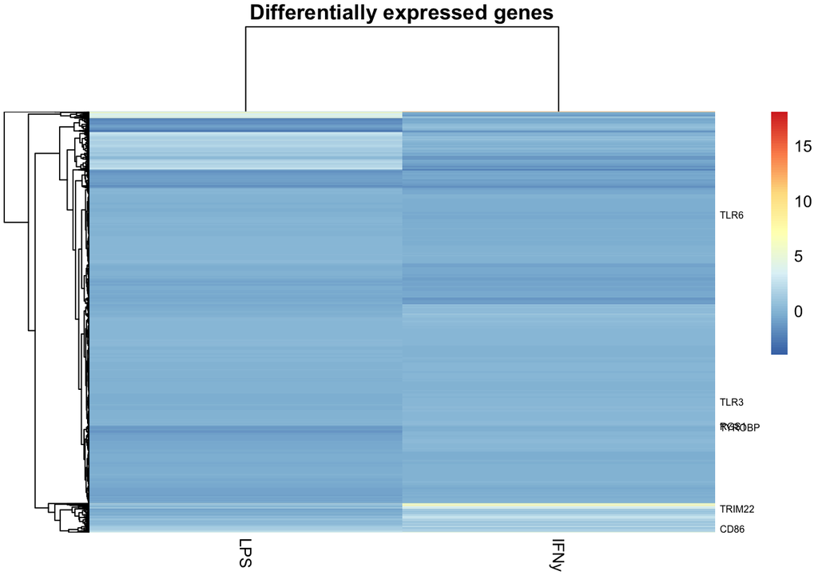

```r
rownames(DF_log2FC) = DF_log2FC$symbol
genelist <- c("RGS1", "TLR6", "TYROBP", "TRIM22", "CD86", "TLR3"   )

labels <- rownames(DF_log2FC)
labels[!labels %in% genelist] <- ""
pheatmap(df_num_scale, labels_row = labels, main = "Differentially expressed genes", fontsize_row =6)
```

### Correlation logFC between LPS and IFNy (spearman)

#6571 genes

```r
df <- as.data.frame(df_num_scale)
res <- cor.test(df$LPS, df$IFNy, method = "spearman")
res
```

```
Spearman's rank correlation rho
```

data: df$LPS and df$IFNy S = 3.7043e+10, p-value < 2.2e-16 alternative hypothesis: true rho is not equal to 0 sample estimates: rho 0.2162783

### PCA across stimulations

```r
dat <- data.frame(df_num_scale)
stimulation <- colnames(dat)
as.data.frame(stimulation)
```

| stimulation |
| --- |
| LPS |
| IFNy |

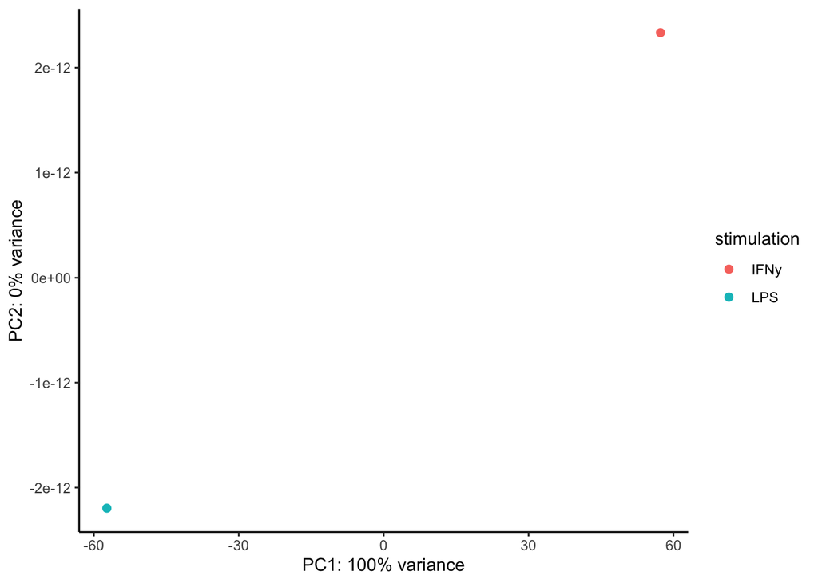

```r
dat <- data.frame(dat)
pca <- prcomp(t(dat), scale=TRUE)
PoV <- round((pca$sdev^2/sum(pca$sdev^2))*100)
#Grab covariates to plot:
library(ggplot2)
library(ggfortify)


#Plot:
ggplot(pca, aes(PC1, PC2, color=stimulation)) +
  geom_point(size=2) +
  xlab(paste0("PC1: ",PoV[1],"% variance")) +
  ylab(paste0("PC2: ",PoV[2],"% variance")) +
  theme_classic()
```

```r
list_filters = list(LPS = genes_LPS, IFNy = genes_IFNy)
#list_filters
overlap = unlist(list_filters)
```

### Upset plot

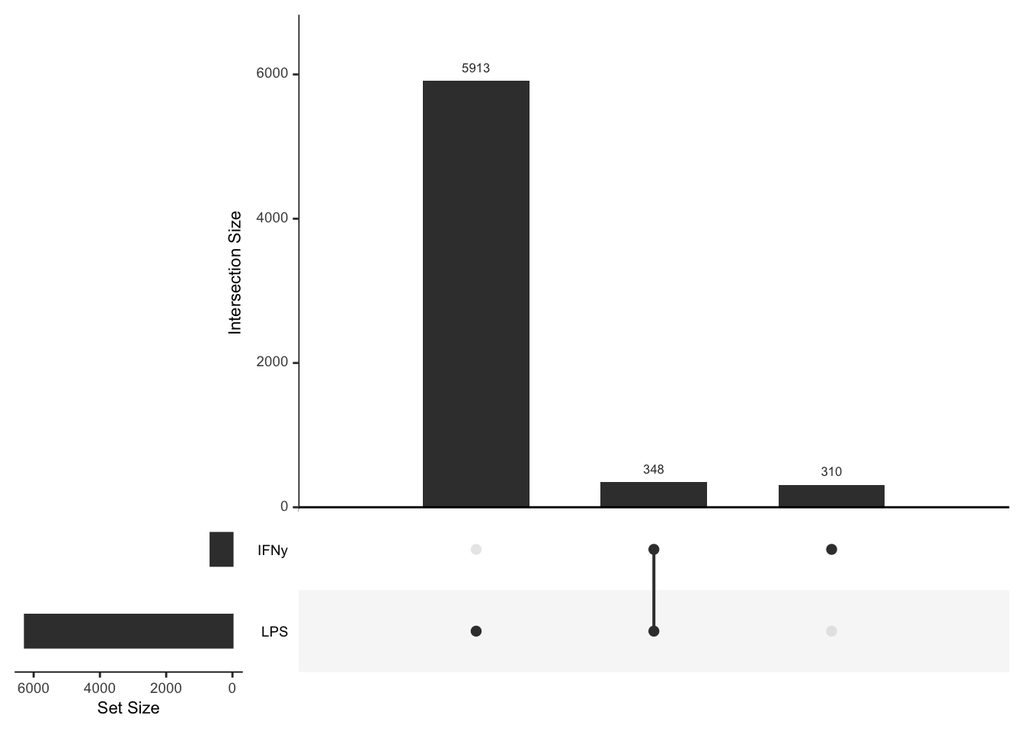

```r
upset(fromList(list_filters), order.by = "freq")
```

# Scatterplots

### LogFC LPS vs IFNy

#18981 genes

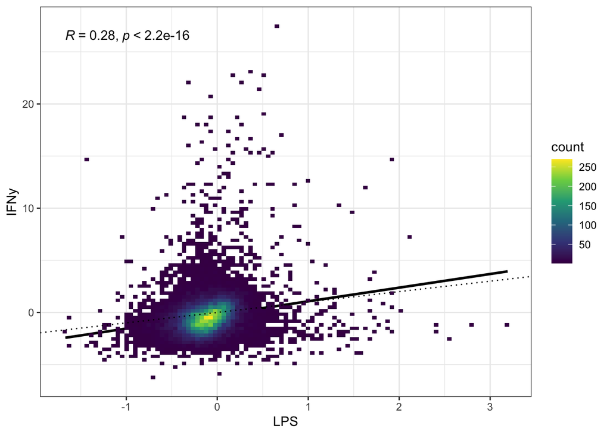

```r
names(res_name_LPS2)[2] <- "LPS"
names(res_name_IFNy2)[2] <- "IFNy"
DEG_genes_LPS_IFNy = merge(res_name_LPS2, res_name_IFNy2, by ="symbol")

LPS <- DEG_genes_LPS_IFNy[,3]
IFNy <- DEG_genes_LPS_IFNy[,12]
df = data.frame(LPS, IFNy)
p <- ggplot(df, aes(x=LPS, y=IFNy) ) +
  geom_smooth(method = "lm", se=FALSE, color="black", formula = y ~ x) +
  geom_bin2d(bins = 100) +
  geom_abline(slope = 1, intercept = 0, linetype = 3) +
  scale_fill_continuous(type = "viridis") +
  theme_bw()
p + stat_cor(method = "spearman")
```